# nlpproject

```python
pip install pandas
```

```
     |████████████████████████████████| 10.0MB 6.2MB/s eta 0:00:01    |█████████████████████████████▏  | 9.2MB 6.2MB/s eta 0:00:01
     |███████████████████████████████▌| 501kB 7.3MB/s eta 0:00:01     |████████████████████████████████| 512kB 7.3MB/s
```

```python
pip install nltk
```

### Importing required libraries

```python
import numpy as np
import pandas as pd # data processing, CSV file I/O (e.g. pd.read_csv)
import matplotlib.pyplot as plt
import re
import nltk
%matplotlib inline
```

```python
from tensorflow import keras
```

```python
!unzip twitter-airline-sentiment.zip
```

```
Archive:  twitter-airline-sentiment.zip
  inflating: Tweets.csv
  inflating: database.sqlite
```

### Exploratory Data Analysis

The data was a free dataset from FigureEight which is a company that offers data as a service.

```python
df= pd.read_csv("Tweets.csv")
df.head()
```

|  | tweet_id | airline_sentiment | airline_sentiment_confidence | negativereason | negativereason_confidence | airline | airline_sentiment_gold | name | negativereason_gold | retweet_count | text | tweet_coord | tweet_created | tweet_location | user_timezone |
| --- | --- | --- | --- | --- | --- | --- | --- | --- | --- | --- | --- | --- | --- | --- | --- |
| 0 | 570306133677760513 | neutral | 1.0000 | NaN | NaN | Virgin America | NaN | cairdin | NaN | 0 | @VirginAmerica What @dhepburn said. | NaN | 2015-02-24 11:35:52 -0800 | NaN | Eastern Time (US & Canada) |
| 1 | 570301130888122368 | positive | 0.3486 | NaN | 0.0000 | Virgin America | NaN | jnardino | NaN | 0 | @VirginAmerica plus you've added commercials t... | NaN | 2015-02-24 11:15:59 -0800 | NaN | Pacific Time (US & Canada) |
| 2 | 570301083672813571 | neutral | 0.6837 | NaN | NaN | Virgin America | NaN | yvonnalynn | NaN | 0 | @VirginAmerica I didn't today... Must mean I n... | NaN | 2015-02-24 11:15:48 -0800 | Lets Play | Central Time (US & Canada) |
| 3 | 570301031407624196 | negative | 1.0000 | Bad Flight | 0.7033 | Virgin America | NaN | jnardino | NaN | 0 | @VirginAmerica it's really aggressive to blast... | NaN | 2015-02-24 11:15:36 -0800 | NaN | Pacific Time (US & Canada) |
| 4 | 570300817074462722 | negative | 1.0000 | Can't Tell | 1.0000 | Virgin America | NaN | jnardino | NaN | 0 | @VirginAmerica and it's a really big bad thing... | NaN | 2015-02-24 11:14:45 -0800 | NaN | Pacific Time (US & Canada) |

Number of null values in each column

```python
df.isna().sum()
```

```
tweet_id                            0
airline_sentiment                   0
airline_sentiment_confidence        0
negativereason                   5462
negativereason_confidence        4118
airline                             0
airline_sentiment_gold          14600
name                                0
negativereason_gold             14608
retweet_count                       0
text                                0
tweet_coord                     13621
tweet_created                       0
tweet_location                   4733
user_timezone                    4820
dtype: int64
```

```python
df.shape
```

```
(14640, 15)
```

Out of 14640 rows most are null for airline_sentiment_gold and negativereason_gold. Therefore, these columns are removed

```python
df.drop(['airline_sentiment_gold','negativereason_gold'],axis=1,inplace=True)
```

```python
df.describe()
```

|  | tweet_id | airline_sentiment_confidence | negativereason_confidence | retweet_count |
| --- | --- | --- | --- | --- |
| count | 1.464000e+04 | 14640.000000 | 10522.000000 | 14640.000000 |
| mean | 5.692184e+17 | 0.900169 | 0.638298 | 0.082650 |
| std | 7.791112e+14 | 0.162830 | 0.330440 | 0.745778 |
| min | 5.675883e+17 | 0.335000 | 0.000000 | 0.000000 |
| 25% | 5.685592e+17 | 0.692300 | 0.360600 | 0.000000 |
| 50% | 5.694779e+17 | 1.000000 | 0.670600 | 0.000000 |
| 75% | 5.698905e+17 | 1.000000 | 1.000000 | 0.000000 |
| max | 5.703106e+17 | 1.000000 | 1.000000 | 44.000000 |

Airlines for which data is available:

```python
airlines = list(df['airline'].unique())
airlines
```

```
['Virgin America', 'United', 'Southwest', 'Delta', 'US Airways', 'American']
```

Data available for each airline

```python
df.groupby('airline')['airline_sentiment'].count().sort_values()
```

```
airline
Virgin America     504
Delta             2222
Southwest         2420
American          2759
US Airways        2913
United            3822
Name: airline_sentiment, dtype: int64
```

### Visualizing Data

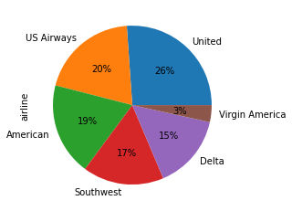

```python
df.airline.value_counts().plot(kind='pie', autopct='%1.0f%%')
```

There is a even distribution of airlines except Virgin America

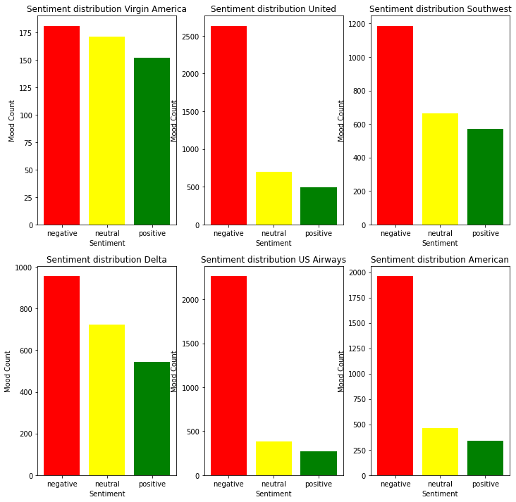

```python
plt.figure(1,figsize=(12, 12))
for i in airlines:
    indices= airlines.index(i)
    plt.subplot(2,3,indices+1)
    new_df=df[df['airline']==i]
    count=new_df['airline_sentiment'].value_counts()
    Index = [1,2,3]
    plt.bar(Index,count, color=['red', 'yellow', 'green'])
    plt.xticks(Index,['negative','neutral','positive'])
    plt.ylabel('Mood Count')
    plt.xlabel('Sentiment')
    plt.title('Sentiment distribution '+i)
```

Mostly tweets at airlines tend to be negative. American airlines and United airlines have heavily negatively skewed distributions.

```python
pip install wordcloud
```

```python
from wordcloud import WordCloud,STOPWORDS
```

```python
neg_df=df[df['airline_sentiment']=='negative']
wordsneg = ' '.join(neg_df['text'])
pos_df=df[df['airline_sentiment']=='positive']
wordspos = ' '.join(pos_df['text'])
```

Preprocessing words to remove links and usernames

```python
def cleaned_word(words):
    return " ".join([word for word in words.split()
                            if 'http' not in word
                                and not word.startswith('@')
                                and word != 'RT'
                            ])
```

Visualizing most common words in negative sentiments tweets

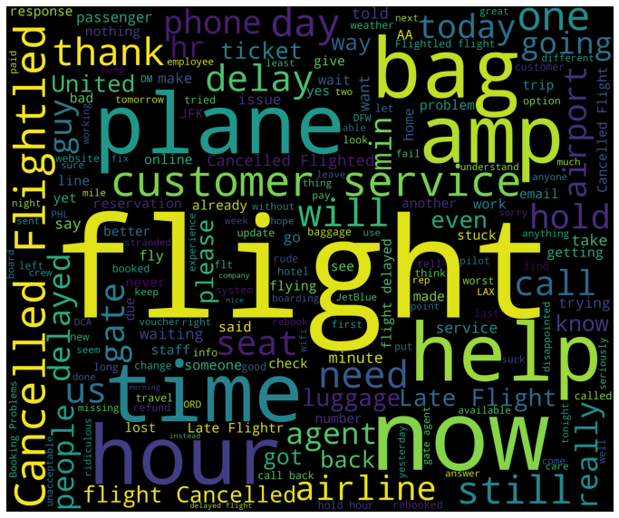

```python
wordcloud = WordCloud(stopwords=STOPWORDS,
                      width=3000,
                      height=2500
                     ).generate(cleaned_word(wordsneg))
plt.figure(1,figsize=(12, 12))
plt.imshow(wordcloud)
plt.axis('off')
plt.show()
```

Visualizing most common words in positive sentiments tweets

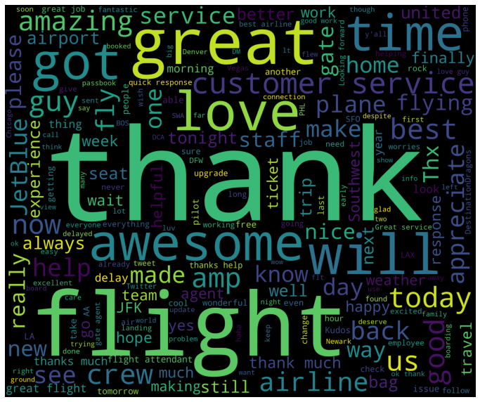

```python
wordcloud = WordCloud(stopwords=STOPWORDS,
                      width=3000,
                      height=2500
                     ).generate(cleaned_word(wordspos))
plt.figure(1,figsize=(12, 12))
plt.imshow(wordcloud)
plt.axis('off')
plt.show()
```

```python
def freq(str):
    d = {"Word":[],"Frequency":[]}
    str = str.split()
    str2 = []
    for i in str:
        if i not in str2:
            str2.append(i)
    for i in range(0, len(str2)):
        if(str.count(str2[i])>50):
            d["Word"].append(str2[i])
            d["Frequency"].append(str.count(str2[i]))
    df = pd.DataFrame.from_dict(d)

    return df
```

Frequency of words in negative sentiment tweets

```python
freq(cleaned_word(wordsneg)).sort_values('Frequency',ascending=False)
```

|  | Word | Frequency |
| --- | --- | --- |
| 2 | to | 5966 |
| 21 | the | 3929 |
| 26 | I | 3375 |
| 9 | a | 3087 |
| 8 | and | 2685 |
| ... | ... | ... |
| 378 | always | 51 |
| 384 | attendant | 51 |
| 355 | pilot | 51 |
| 162 | bag. | 51 |
| 393 | wifi | 51 |

422 rows × 2 columns

Frequency of words in positive sentiment tweets

```python
freq(cleaned_word(wordspos)).sort_values('Frequency',ascending=False)
```

|  | Word | Frequency |
| --- | --- | --- |
| 1 | the | 924 |
| 0 | to | 923 |
| 26 | for | 658 |
| 3 | I | 574 |
| 29 | you | 509 |
| ... | ... | ... |
| 46 | can | 54 |
| 13 | much | 54 |
| 4 | fly | 54 |
| 43 | been | 52 |
| 47 | crew | 51 |

71 rows × 2 columns

Most common negative reasons

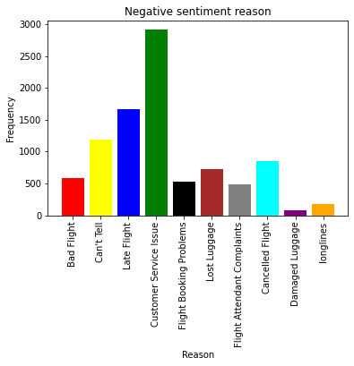

```python
df['negativereason'].nunique()

NR_Count=dict(df['negativereason'].value_counts(sort=False))
def NR_Count(Airline):
    if Airline=='All':
        a=df
    else:
        a=df[df['airline']==Airline]
    count=dict(a['negativereason'].value_counts())
    Unique_reason=list(df['negativereason'].unique())
    Unique_reason=[x for x in Unique_reason if str(x) != 'nan']
    Reason_frame=pd.DataFrame({'Reasons':Unique_reason})
    Reason_frame['count']=Reason_frame['Reasons'].apply(lambda x: count[x])
    return Reason_frame
def plot_reason(Airline):

    a=NR_Count(Airline)
    count=a['count']
    Index = range(1,(len(a)+1))
    plt.bar(Index,count, color=['red','yellow','blue','green','black','brown','gray','cyan','purple','orange'])
    plt.xticks(Index,a['Reasons'],rotation=90)
    plt.ylabel('Frequency')
    plt.xlabel('Reason')
    plt.title('Negative sentiment reason')

plot_reason('All')
```

```python
def tweet_to_words(tweet):
    tweet = tweet.lower()
    tweet = re.sub(r'\W+' , ' ' , tweet )
    tokens = word_tokenize(tweet)
    stop_words = stopwords.words('english')
    return [i for i in tokens if i not in stop_words ]
```

```python
nltk.download('stopwords')
nltk.download('punkt')
```

```
True
```

```python
from nltk.corpus import stopwords
from nltk.tokenize import word_tokenize
import gensim
```

```python
all = []
X = df['text'].values
for i in range(0,len(X)):
  all.append(tweet_to_words(X[i]))
```

Words most similar

```python
model = gensim.models.Word2Vec( all , size = 50 , window = 5 , min_count = 1, workers = 2, sg=1 )
```

```python
test1 = model.most_similar("nice" , topn = 5 )
test2 = model.most_similar("bad" , topn = 5 )
```

```python
test1
```

```
[('appreciated', 0.9784284234046936),
 ('think', 0.9769712090492249),
 ('say', 0.9698835611343384),
 ('glad', 0.967129647731781),
 ('right', 0.9666367769241333)]
```

```python
test2
```

```
[('disappointed', 0.9607664942741394),
 ('lack', 0.9568771719932556),
 ('worse', 0.9539422392845154),
 ('poor', 0.9525032639503479),
 ('awful', 0.9503002762794495)]
```

### LSTM

```python
#word embedding
we =[]
for i in all   :
    X = np.zeros((50))
    for j in i :
        X = X + model[j] #sum of word embeddings
    we.append(X)
```

```python
we[:2]
```

```
[array([-0.9798112 ,  0.47818195, -0.38789961,  0.4558548 ,  0.02654453,
        -0.13398713,  0.4047261 ,  0.02354546, -0.13053055,  0.04187811,
        -0.47678587,  1.51263923,  0.21737398,  0.46859627, -0.08293586,
        -0.21225463,  0.92883598, -0.70239649,  0.58550548, -0.22459746,
         0.43932033, -0.32656616,  0.63066471, -0.20984171,  1.32525703,
        -0.02514381, -1.08882221,  0.94345061, -0.25287958, -0.25475258,
        -0.10606027,  0.88472369, -0.25786858, -0.0876932 ,  0.64522671,
         0.11795031,  0.13250042,  1.10382062, -0.65353742, -1.47374883,
        -0.77232463, -0.09303861,  0.5540774 ,  0.98895628, -0.20277183,
        -0.63767302,  0.18997236, -0.53804189,  0.75067398, -0.40691351]),
 array([-2.05356341,  1.02308017, -0.49809638,  0.6958138 , -0.06237395,
        -0.66479317,  0.22260111,  0.19956139, -0.2370692 , -0.46001472,
        -1.95162526,  2.92173894,  0.53319106,  1.20576728,  0.03767586,
        -0.14171476,  1.90668373, -1.84721657,  0.73514303, -0.71756437,
         0.72401309, -1.16072335,  2.07598504, -0.067411  ,  3.05003743,
         0.18008516, -2.52455018,  1.72693047, -0.19405945, -0.14166631,
        -0.25096543,  2.51583695, -1.04099916, -0.90167532,  1.12534981,
         0.28058544,  0.84597539,  1.86551751, -0.86552472, -3.97058181,
        -1.71066976, -0.68681056,  1.16867936,  2.12721752,  0.01316249,
        -1.32909822,  0.73259311, -0.91353704,  1.05577717, -0.86571795])]
```

```python
len(we)
```

```
14640
```

```python
Y = df['airline_sentiment'].values
```

```python
len(Y)
```

```
14640
```

Converting labels to int

```python
for i in range(len(Y)):
    Y[i] = Y[i].lower()
    if Y[i] == "neutral":
        Y[i] = 2
    elif Y[i]=="positive":
        Y[i] = 1
    else:
        Y[i] = 0
```

```python
from sklearn.model_selection import train_test_split
```

```python
we = np.array(we)
X_train,X_test,Y_train,Y_test = train_test_split( we , Y , test_size = 0.4 )
```

```python
X_train = X_train.reshape( X_train.shape[0] , 1 , X_train.shape[1] )
X_test = X_test.reshape( X_test.shape[0] , 1 , X_test.shape[1] )
Y_test = keras.utils.to_categorical(Y_test  , num_classes = 3 )
Y_train = keras.utils.to_categorical(Y_train , num_classes = 3 )
```

```python
X_train.shape
```

```
(8784, 1, 50)
```

Network structure:

1. LSTM layer
2. 3 fully connected layers with relu activation
3. Final layer with 3 outputs and softmax activation

```python
modell = keras.Sequential()
modell.add(keras.layers.LSTM(50,input_shape=(1, 50)))
modell.add(keras.layers.Dense(30, activation='relu'))
modell.add(keras.layers.Dense(20, activation='relu'))
modell.add(keras.layers.Dense(10, activation='relu'))
modell.add(keras.layers.Dense(3, activation='softmax'))
modell.compile(loss='categorical_crossentropy', optimizer='adam' , metrics=['accuracy'])
print(modell.summary())
history = modell.fit(X_train, Y_train , epochs = 50 , batch_size = 64 ,  verbose=1 )
```

```
Model: "sequential_15"
_________________________________________________________________
Layer (type)                 Output Shape              Param #
=================================================================
lstm_15 (LSTM)               (None, 50)                20200
_________________________________________________________________
dense_56 (Dense)             (None, 30)                1530
_________________________________________________________________
dense_57 (Dense)             (None, 20)                620
_________________________________________________________________
dense_58 (Dense)             (None, 10)                210
_________________________________________________________________
dense_59 (Dense)             (None, 3)                 33
=================================================================
Total params: 22,593
Trainable params: 22,593
Non-trainable params: 0
_________________________________________________________________
None
```

```python
print(modell.metrics_names)
```

```
['loss', 'accuracy']
```

```python
print(modell.evaluate( X_test , Y_test , verbose = 0 ) )
```

```
[0.629410982131958, 0.7457308769226074]
```

```python
# Model Using Average
wea = []
for i in all   :
    X = np.zeros((50))
    for j in i :
        X = X + model[j]
    X /= len( i ) #average word embedding
    wea.append(X)
```

```python
wea = np.array(wea)
X_train,X_test,Y_train,Y_test = train_test_split( wea , Y , test_size = 0.4 )
X_train = X_train.reshape( X_train.shape[0] , 1 , X_train.shape[1] )
X_test = X_test.reshape( X_test.shape[0] , 1 , X_test.shape[1] )
Y_test = keras.utils.to_categorical(Y_test  , num_classes = 3 )
Y_train = keras.utils.to_categorical(Y_train , num_classes = 3 )
```

```python
model2 = keras.Sequential()
model2.add(keras.layers.LSTM(50,input_shape=(1, 50)))
model2.add(keras.layers.Dense(30, activation='relu'))
model2.add(keras.layers.Dense(20, activation='relu'))
model2.add(keras.layers.Dense(10, activation='relu'))
model2.add(keras.layers.Dense(3, activation='softmax'))
model2.compile(loss='categorical_crossentropy', optimizer='adam' , metrics=['accuracy'])
print(modell.summary())
history = model2.fit(X_train, Y_train , epochs = 50 , batch_size = 64 ,  verbose=1 )
```

```
Model: "sequential_15"
_________________________________________________________________
Layer (type)                 Output Shape              Param #
=================================================================
lstm_15 (LSTM)               (None, 50)                20200
_________________________________________________________________
dense_56 (Dense)             (None, 30)                1530
_________________________________________________________________
dense_57 (Dense)             (None, 20)                620
_________________________________________________________________
dense_58 (Dense)             (None, 10)                210
_________________________________________________________________
dense_59 (Dense)             (None, 3)                 33
=================================================================
Total params: 22,593
Trainable params: 22,593
Non-trainable params: 0
_________________________________________________________________
None
```

```python
print(model2.evaluate( X_test , Y_test , verbose = 0 ) )
```

```
[0.6312038898468018, 0.7380464673042297]
```

#### In this case sum of word embeddings is more accurate than average of word embeddings

### Testing custom queries

```python
def classifyinput(inputt):
    preprocessed = tweet_to_words(inputt)
    we =[]
    #sum of word embedding
    for i in preprocessed   :
        X = np.zeros((50))
        try:
            X = X + model[i]
        except:
            continue
    we.append(X)
    we = np.array(we)
    we = we.reshape( we.shape[0] , 1 , we.shape[1] )
    sentiment = modell.predict(we).argmax()
    if sentiment == 0 :
        return "Negative"
    elif sentiment == 1 :
        return "Poitive"
    elif sentiment == 2:
        return "Neutral"
    else:
        return "Invalid output"
```

```python
classifyinput("Just had a great flight from Singapore to London with @VirginAmerica. Food was amazing")
```

```
'Poitive'
```

```python
classifyinput("My @DeltaAirlines was flight was cancelled after a 3 hour delay. Terrible service!")
```

```
'Negative'
```

```python
classifyinput("Just flew with @United to LAX")
```

```
'Neutral'
```